# Targeting Annotations

James R. Walters

# Introduction

Upon review, referees have asked for further annotation of proteins, specifically for annotations from:

- SignalP: https://services.healthtech.dtu.dk/services/SignalP-6.0/
- TargetP: https://services.healthtech.dtu.dk/services/TargetP-2.0/
- TMHMM: https://services.healthtech.dtu.dk/services/TMHMM-2.0/

I submitted to these servers and am now parsing results.

```r
# load needed libraries
library(kableExtra)
library(tidyverse)
```

# Load data

```r
sigPColNames <- c("GeneID", "SigP_Pred",    "SigP_OTHER",   "SigP_SP",  "SigP_CSPos")
signalP1 <- read.table(file = "../SignalP-TM-TargetP_Outputs/SignalP_chunk1_out/prediction_results.txt",
                       skip = 2, col.names = sigPColNames, sep = "\t")
signalP2 <- read.table(file = "../SignalP-TM-TargetP_Outputs/SignalP_chunk2_out/prediction_results.txt",
                       skip = 2, col.names = sigPColNames, sep = "\t")

sigP <- rbind(signalP1,signalP2)
# Identifier has complete fasta header.
# Only need GeneID, so remove rest.
sigP$GeneID <- sub("\\s.*$", "", sigP$GeneID)
str(sigP)
```

```
## 'data.frame':    1647 obs. of  5 variables:
##  $ GeneID    : chr  "PIERAPG00000012191" "PIERAPG00000008472" "PIERAPG00000008588" "PIERAPG00000009252" ...
##  $ SigP_Pred : chr  "OTHER" "OTHER" "OTHER" "OTHER" ...
##  $ SigP_OTHER: num  1 1 1 1 1 ...
##  $ SigP_SP   : num  0.000293 0.000003 0.000002 0 0 ...
##  $ SigP_CSPos: chr  "" "" "" "" ...
```

```r
table(sigP$SigP_Pred)
```

```
##
## OTHER    SP
##  1358   289
```

## TargetP

```r
targetPColNames <- c("GeneID",  "TargP_Pred",   "TargP_OTHER",  "TargP_SP", "TargP_mTP",    "TargP_CSPos")
targetP <- read.table(file = "../SignalP-TM-TargetP_Outputs/TargetP_out.txt", skip = 2,
                      col.names = targetPColNames, sep = "\t")
str(targetP)
```

```
## 'data.frame':    1647 obs. of  6 variables:
##  $ GeneID     : chr  "PIERAPG00000012191" "PIERAPG00000008472" "PIERAPG00000008588" "PIERAPG00000009252" ...
##  $ TargP_Pred : chr  "mTP" "OTHER" "OTHER" "OTHER" ...
##  $ TargP_OTHER: num  0.0504 1 0.9999 0.9999 1 ...
##  $ TargP_SP   : num  0.001962 0.000004 0.000051 0.000022 0 ...
##  $ TargP_mTP  : num  0.947599 0.000008 0.000023 0.000108 0.00001 ...
##  $ TargP_CSPos: chr  "CS pos: 31-32. RRN-AG. Pr: 0.5179" "" "" "" ...
```

```r
table(targetP$TargP_Pred)
```

```
##
##   mTP OTHER    SP
##    94  1217   336
```

## TMHMM

TMHMM manual for interpretation: https://services.healthtech.dtu.dk/services/TMHMM-2.0/2-Guide.php

```r
tmColNames <- c("GeneID", "length", "expAA", "first60", "PredHel", "Topology")
tmhmm <- read.table(file = "../SignalP-TM-TargetP_Outputs/TMHMM_out.txt",
                    col.names = tmColNames)

tmhmm$length <- as.numeric(sub(pattern = "len=", replacement = "",
                              tmhmm$length))
tmhmm$expAA <- as.numeric(sub(pattern = "ExpAA=", replacement = "",
                              tmhmm$expAA))
tmhmm$first60 <- as.numeric(sub(pattern = "First60=", replacement = "",
                              tmhmm$first60))
tmhmm$PredHel <- as.numeric(sub(pattern = "PredHel=", replacement = "",
                              tmhmm$PredHel))
tmhmm$Topology <- sub(pattern = "Topology=", replacement = "",
                              tmhmm$Topology)
# Add binary result, true if transmembrane predicted
tmhmm$transmem <- tmhmm$PredHel > 0


str(tmhmm)
```

```
## 'data.frame':    1647 obs. of  7 variables:
##  $ GeneID  : chr  "PIERAPG00000012191" "PIERAPG00000008472" "PIERAPG00000008588" "PIERAPG00000009252" ...
##  $ length  : num  150 1017 247 144 252 ...
##  $ expAA   : num  22.79 0.04 0.16 2.88 0.01 ...
##  $ first60 : num  1.25 0.04 0 0 0.01 0.03 0.34 1.67 0.02 0 ...
##  $ PredHel : num  1 0 0 0 0 0 1 0 0 1 ...
##  $ Topology: chr  "o61-83i" "o" "o" "i" ...
##  $ transmem: logi  TRUE FALSE FALSE FALSE FALSE FALSE ...
```

```r
#
table(tmhmm$transmem)
```

```
##
## FALSE  TRUE
##  1463   184
```

# Merge data

Let’s combine these new annotations from the DTU resources into a single dataframe.

```r
dtuAnno <- merge(x = sigP, y = targetP, by = "GeneID")
dtuAnno <- merge(x = dtuAnno, y = tmhmm, by = "GeneID")
str(dtuAnno)
```

```
## 'data.frame':    1647 obs. of  16 variables:
##  $ GeneID     : chr  "PIERAPG00000000011" "PIERAPG00000000015" "PIERAPG00000000017" "PIERAPG00000000023" ...
##  $ SigP_Pred  : chr  "OTHER" "SP" "SP" "OTHER" ...
##  $ SigP_OTHER : num  1 0.173 0.429 1 1 ...
##  $ SigP_SP    : num  0 0.827015 0.571208 0.000002 0 ...
##  $ SigP_CSPos : chr  "" "CS pos: 17-18. Pr: 0.7941" "CS pos: 20-21. Pr: 0.6166" "" ...
##  $ TargP_Pred : chr  "OTHER" "SP" "SP" "OTHER" ...
##  $ TargP_OTHER: num  0.9996 0.0405 0.0223 0.9976 0.1887 ...
##  $ TargP_SP   : num  0.000317 0.959459 0.977418 0.000771 0.000071 ...
##  $ TargP_mTP  : num  0.000121 0.00003 0.000294 0.001579 0.811246 ...
##  $ TargP_CSPos: chr  "" "CS pos: 17-18. VSG-KD. Pr: 0.9556" "CS pos: 20-21. XQS-ER. Pr: 0.6821" "" ...
##  $ length     : num  686 166 132 204 522 874 161 279 224 131 ...
##  $ expAA      : num  0.33 0.08 12.79 0.7 15.52 ...
##  $ first60    : num  0 0.08 6.41 0.02 0 0 2.52 0 0.04 0 ...
##  $ PredHel    : num  0 0 0 0 1 0 1 0 0 0 ...
##  $ Topology   : chr  "o" "o" "o" "o" ...
##  $ transmem   : logi  FALSE FALSE FALSE FALSE TRUE FALSE ...
```

And then we can merge these with all the other annotations we have so far.

```r
# loads `merge_by_gene` from previous annotation script
load("../Results/PANNZER.BLAST.DE_Merged.Rdata")
allAnno <- merge(x = merge_by_gene, y = dtuAnno, by = "GeneID")
# str(allAnno)
```

and save it out to file.

```r
write.csv( x = allAnno, file = "../Results/PrapaeSpermProts_allAnnot.csv", row.names = TRUE)
save(allAnno, file = "../Results/PrapaeSpermProts_allAnnot.Rdata" )
```

# Annotations by sperm subset

Now we can do some cross-referencing of annotations by proteome subset.

## Signal P

First for signal peptides.

```r
sigPsubset <- table(allAnno$SigP_Pred, allAnno$master.de)
sigPsubset.prop <- prop.table(sigPsubset, margin = 2)

kable(sigPsubset)
```

|  | apyrene | eupyrene | unbiased |
| --- | --- | --- | --- |
| OTHER | 110 | 100 | 1159 |
| SP | 15 | 50 | 228 |

```r
kable(round(sigPsubset.prop, digits = 3))
```

|  | apyrene | eupyrene | unbiased |
| --- | --- | --- | --- |
| OTHER | 0.88 | 0.667 | 0.836 |
| SP | 0.12 | 0.333 | 0.164 |

```r
sigPchisq <- chisq.test(x = sigPsubset)

sigPchisq
```

```
##
##  Pearson's Chi-squared test
##
## data:  sigPsubset
## X-squared = 29.557, df = 2, p-value = 3.818e-07
```

```r
sigPchisq$stdres
```

```
##
##           apyrene  eupyrene  unbiased
##   OTHER  1.717466 -5.291639  2.861520
##   SP    -1.717466  5.291639 -2.861520
```

Seems clear that Eupyrene-biased proteins are enriched for signal peptides. When chisq standardized residuals > |3|, indicates a strong deviation from expected.

## Target P

Let’s now do the same for targeting peptides. In particular, we want to focus on mitochondrial targeting peptides.

```r
targPsubset <- table(allAnno$TargP_Pred, allAnno$master.de)
targPsubset.prop <- prop.table(targPsubset, margin = 2)

kable(targPsubset)
```

|  | apyrene | eupyrene | unbiased |
| --- | --- | --- | --- |
| mTP | 17 | 3 | 74 |
| OTHER | 90 | 86 | 1051 |
| SP | 18 | 61 | 262 |

```r
kable(round(targPsubset.prop, digits = 3))
```

|  | apyrene | eupyrene | unbiased |
| --- | --- | --- | --- |
| mTP | 0.136 | 0.020 | 0.053 |
| OTHER | 0.720 | 0.573 | 0.758 |
| SP | 0.144 | 0.407 | 0.189 |

Since we don’t care about signal peptide predictions from the `TargetP` results, I will merge these with `OTHER` to make it a binary result for `mTP`

```r
mtpSubset <- targPsubset
mtpSubset[2,] <- mtpSubset[2,] + mtpSubset[3,]
mtpSubset <- mtpSubset[1:2,]
mtpSubset.prop <- prop.table(mtpSubset, margin = 2)

kable(mtpSubset)
```

|  | apyrene | eupyrene | unbiased |
| --- | --- | --- | --- |
| mTP | 17 | 3 | 74 |
| OTHER | 108 | 147 | 1313 |

```r
kable(round(mtpSubset.prop, digits = 3))
```

|  | apyrene | eupyrene | unbiased |
| --- | --- | --- | --- |
| mTP | 0.136 | 0.02 | 0.053 |
| OTHER | 0.864 | 0.98 | 0.947 |

```r
targPchisq <- chisq.test(x = mtpSubset)

targPchisq
```

```
##
##  Pearson's Chi-squared test
##
## data:  mtpSubset
## X-squared = 18.808, df = 2, p-value = 8.238e-05
```

```r
targPchisq$stdres
```

```
##
##           apyrene  eupyrene  unbiased
##   mTP    3.998304 -2.032198 -1.270628
##   OTHER -3.998304  2.032198  1.270628
```

# Transmembrane

Now test for differences in presence of transmembrane protein.

```r
tmsubset <- table(allAnno$transmem, allAnno$master.de)
tmsubset.prop <- prop.table(tmsubset, margin = 2)

kable(tmsubset)
```

|  | apyrene | eupyrene | unbiased |
| --- | --- | --- | --- |
| FALSE | 100 | 128 | 1247 |
| TRUE | 25 | 22 | 140 |

```r
kable(round(tmsubset.prop, digits = 3))
```

|  | apyrene | eupyrene | unbiased |
| --- | --- | --- | --- |
| FALSE | 0.8 | 0.853 | 0.899 |
| TRUE | 0.2 | 0.147 | 0.101 |

```r
tmchisq <- chisq.test(x = tmsubset)

tmchisq
```

```
##
##  Pearson's Chi-squared test
##
## data:  tmsubset
## X-squared = 13.195, df = 2, p-value = 0.001364
```

```r
tmchisq$stdres
```

```
##
##           apyrene  eupyrene  unbiased
##   FALSE -3.218705 -1.387749  3.354489
##   TRUE   3.218705  1.387749 -3.354489
```

So there is a significant difference, but it is not as obvious that one group is an outlier. It is hard to make much of this result, in light of the other results for signalP and mtP.

# Plotting

## Tidy data

Let’s do some work to visualize this. It would probably be nicer to see it visually than in a table.

First, clean up the objects for reasonable labelling

```r
subsetNames <- c("Apyrene", "Eupyrene", "Unbiased")
colnames(sigPsubset.prop) <- subsetNames
colnames(mtpSubset.prop) <- subsetNames

annoRownames <- c("Absent", "Present")
rownames(sigPsubset.prop) <- annoRownames
rownames(mtpSubset.prop) <- rev(annoRownames)
```

```r
# Function to convert to tidy
prop_table_to_tidy <- function(x, annotation_name, present_row) {
  df <- as.data.frame(x)

  # Case 1: x was a table -> df has Var1/Var2/Freq
  if (all(c("Var1", "Var2", "Freq") %in% names(df))) {
    df %>%
      transmute(
        annotation = annotation_name,
        class = as.character(Var1),
        subset = as.character(Var2),
        prop = as.numeric(Freq),
        status = if_else(class == present_row, "Present", "Absent")
      ) %>%
      select(annotation, subset, status, prop)

  } else {
    # Case 2: x was a matrix/data.frame with rownames = class, cols = subsets
    df %>%
      tibble::rownames_to_column("class") %>%
      pivot_longer(cols = -class, names_to = "subset", values_to = "prop") %>%
      mutate(
        annotation = annotation_name,
        status = if_else(class == present_row, "Present", "Absent"),
        prop = as.numeric(prop)
      ) %>%
      select(annotation, subset, status, prop)
  }
}





df_sigp <- prop_table_to_tidy(sigPsubset.prop,
                             annotation_name = "Signal peptide",
                             present_row = "Present")

df_mtp  <- prop_table_to_tidy(mtpSubset.prop,
                             annotation_name = "Mitochondrial targeting peptide",
                             present_row = "Present")

df_all <- bind_rows(df_sigp, df_mtp) %>%
  mutate(
    subset = factor(subset, levels = subsetNames),
    status = factor(status, levels = rev(annoRownames))
  )

str(df_all)
```

```
## 'data.frame':    12 obs. of  4 variables:
##  $ annotation: chr  "Signal peptide" "Signal peptide" "Signal peptide" "Signal peptide" ...
##  $ subset    : Factor w/ 3 levels "Apyrene","Eupyrene",..: 1 1 2 2 3 3 1 1 2 2 ...
##  $ status    : Factor w/ 2 levels "Present","Absent": 2 1 2 1 2 1 1 2 1 2 ...
##  $ prop      : num  0.88 0.12 0.667 0.333 0.836 ...
```

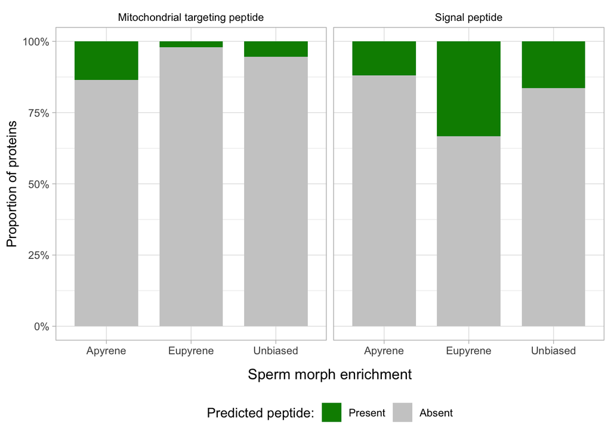

```r
present_absent_cols <- c(
  "Present" = "green4",  # dark, muted green
  "Absent"   = "grey80"
)


annoPlot <- ggplot(df_all, aes(x = subset, y = prop, fill = status)) +
  geom_col(width = 0.75) +
  facet_wrap(~ annotation, nrow = 1) +
  scale_fill_manual(values = present_absent_cols) +
  scale_y_continuous(labels = scales::percent_format(accuracy = 1), limits = c(0, 1)) +
  labs(x = "Sperm morph enrichment",
       y = "Proportion of proteins",
       fill = "Predicted peptide:") +
  theme_light() +
  theme(
    legend.position = "bottom",
    strip.background = element_blank(),
    strip.text = element_text(color = "black"),
    axis.title.x = element_text(size = 12,
                                margin = margin(t = 10))
  )

annoPlot
```

```r
#PDF
ggsave(plot = annoPlot, filename = "../Results/PeptidePredictBarPlot.pdf",
       width = 85 , height = 60, units = "mm", scale = 1.5)
#JPG
ggsave(plot = annoPlot, filename = "../Results/PeptidePredictBarPlot.jpg",
       width = 85 , height = 60, units = "mm", scale = 1.5)
```